# HW 02

Author

Cedric Destin

## 1 - A new day, a new plot, a new geom

```r
options(warn=-1)
if (!require("pacman"))
  install.packages("pacman")
# use this line for installing/loading
pacman::p_load(tidyverse,
               glue,
               scales,
               openintro,
               gridExtra,
               ggrepel,
               ggmap,
               ggridges,
               dsbox,
               devtools,
               fs,
               janitor,
               here,
               dplyr,
               palmerpenguins,
               stringr,
               ggplot2)
```

**A new day, a new plot, a new geom.** The goal of this exercise is to learn about a new type of plot (ridgeline plot) and to learn how to make it.

Use the `geom_density_ridges()` function from the **ggridges** package to make a ridge plot of of Airbnb review scores of Edinburgh neighborhoods. *The neighborhoods should be ordered by their median review scores.* The data can be found in the **dsbox** package, and it’s called `edibnb`. *Also include an interpretation for your visualization.* You should review feedback from your Homework 1 to make sure you capture anything you may have missed previously.

*(Note:* This is not a geom we introduced in class, so seeing an example of it in action will be helpful. Read the package README at https://wilkelab.org/ggridges and/or the introduction vignette at https://wilkelab.org/ggridges/articles/introduction.html. There is more information than you need for this question in the vignette; the first section on Geoms should be sufficient to help you get started.)

```r
devtools::install_github("tidyverse/dsbox")
library(dsbox)
my_edibnb_data <- edibnb
```

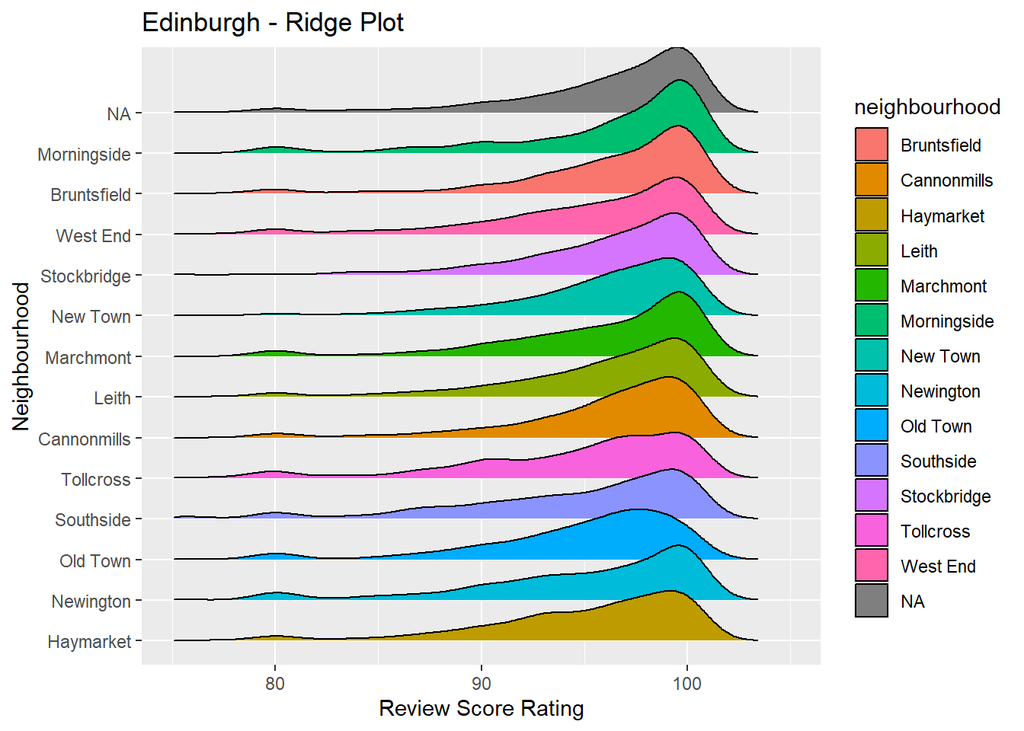

```r
library(ggplot2)
library(ggridges)

ggplot(my_edibnb_data %>% filter(!is.na(review_scores_rating)),
       aes(x = review_scores_rating,
           y = fct_reorder(neighbourhood,
                           review_scores_rating, .fun = median),
           fill = neighbourhood)) +
  geom_density_ridges() +
  xlim(75, 105) +
  labs(title = "Edinburgh - Ridge Plot",
      x = "Review Score Rating",
      y = "Neighbourhood")
```

Sources:

1. https://wilkelab.org/ggridges
2. https://forcats.tidyverse.org/reference/fct_reorder.html

## Foreign Connected PACs

```r
# get a list of files with "Foreign Connected PAC" in their names
list_of_files <- dir_ls(path = "data",
                        regexp = "Foreign Connected PAC")
pac <- read_csv(list_of_files, id = "year", show_col_types = FALSE)
```

```r
pac <- pac |>
  mutate(
    # Create a new column named 'election_year'
    year = str_extract(year, "(?<=-)\\d{4}"),

    # Convert the new column from text to a number (optional but recommended)
    year = as.numeric(year),
    pac_name_affiliate = `PAC Name (Affiliate)`,
    Democrat = as.numeric(str_extract(Dems, "\\d+")),
    Republican = as.numeric(str_extract(Repubs, "\\d+"))
  )

pac <- pac |>
  separate(
    col = `Country of Origin/Parent Company`,
    into = c("country", "parent_company"),
    sep = "/",
    extra = "merge",
    remove = TRUE
  )

pac <- pac |>
  select(-`PAC Name (Affiliate)`)
pac <- pac |>
  select(-Dems)
pac <- pac |>
  select(-Repubs)
pac <- pac |>
  select(-Total)
```

```r
pac <- pac %>%
  pivot_longer(
    cols = c(Democrat, Republican),
    names_to = "party",
    values_to = "amount"
  )

head(pac)
```

```
# A tibble: 6 × 6
   year country     parent_company    pac_name_affiliate party      amount
  <dbl> <chr>       <chr>             <chr>              <chr>       <dbl>
1  2000 Japan       Ito-Yokado        7-Eleven           Democrat     1500
2  2000 Japan       Ito-Yokado        7-Eleven           Republican   7000
3  2000 Switzerland Asea Brown Boveri ABB Group          Democrat    17000
4  2000 Switzerland Asea Brown Boveri ABB Group          Republican  28500
5  2000 UK          Accenture plc     Accenture          Democrat    23000
6  2000 UK          Accenture plc     Accenture          Republican  52984
```

```r
sum_per_category <- pac %>%
  group_by(year, party, country) %>%
  summarize(Total_Value = sum(amount), .groups = "keep")
```

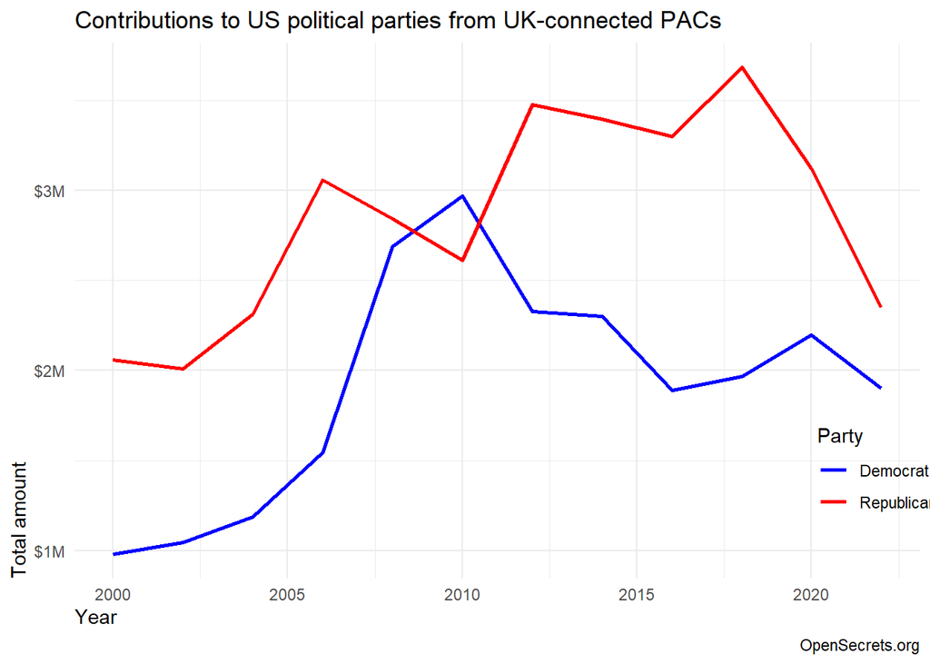

```r
ggplot(data = filter(sum_per_category, country == "UK"),
          aes(x = year,
              y = Total_Value,
              group = party,
              color = party)
       ) +
  geom_line(linewidth = 1) +
  guides(color = guide_legend(title = "Party")) +
  scale_color_manual(values = c("blue", "red")) +
  scale_y_continuous(labels = function(x) paste0("$", x/1000000, "M")) +
  theme_minimal() +
  theme(legend.position = "inside",
      legend.position.inside = c(0.95,0.2),
      axis.title.x = element_text(hjust=0),
      axis.title.y = element_text(hjust=0)) +
  labs(title = "Contributions to US political parties from UK-connected PACs",
       x = "Year",
       y = "Total amount",
       caption = "OpenSecrets.org")
```

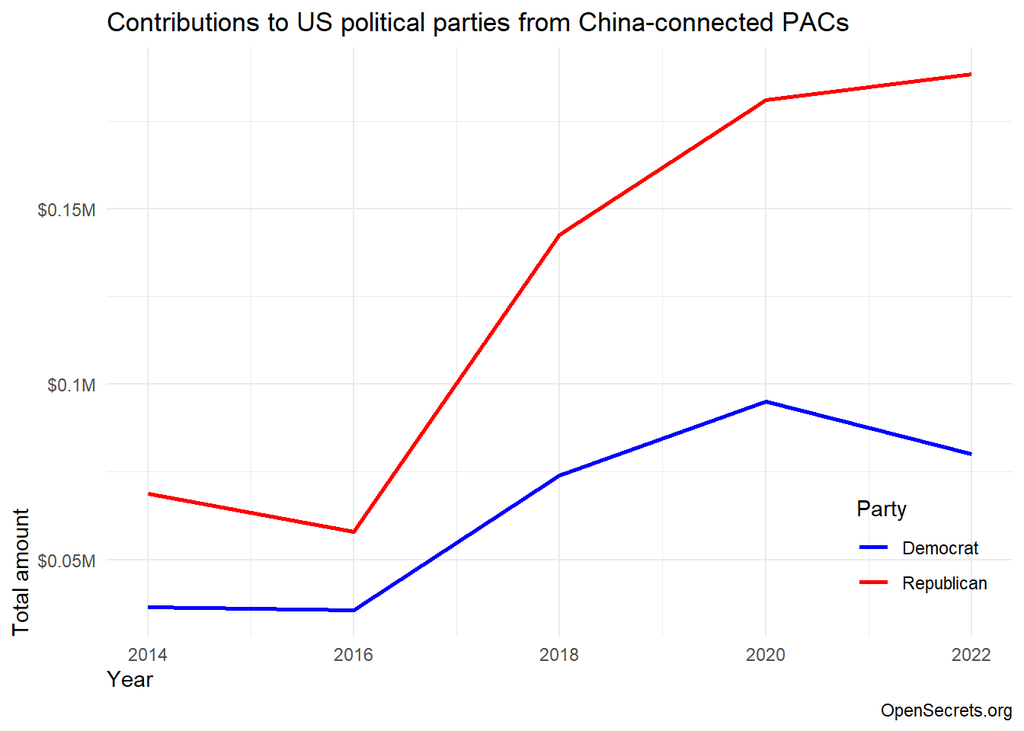

```r
ggplot(data = filter(sum_per_category, country == "China"),
          aes(x = year,
              y = Total_Value,
              group = party,
              color = party)
       ) +
  geom_line(linewidth = 1) +
  guides(color = guide_legend(title = "Party")) +
  scale_color_manual(values = c("blue", "red")) +
  scale_y_continuous(labels = function(x) paste0("$", x/1000000, "M")) +
  theme_minimal() +
  theme(legend.position = "inside",
      legend.position.inside = c(0.9,0.15),
      axis.title.x = element_text(hjust=0),
      axis.title.y = element_text(hjust=0)) +
  labs(title = "Contributions to US political parties from China-connected PACs",
       x = "Year",
       y = "Total amount",
       caption = "OpenSecrets.org")
```

**Observations**: This last data that was just made is very interesting! Although the Chinese affiliated countries invested less than the UK affiliated countries, the Chinese affiliated countries increased the total contributions to the US elections increased over the years. And despite the Republicans being against the Chinese government, the Republican donations still increased in the recent years.

## 3 - Median housing prices in the US

```r
housing <- read_csv(here("data", "median-housing.csv"),
                    show_col_types = FALSE)
names(housing) <- c("date", "price")
```

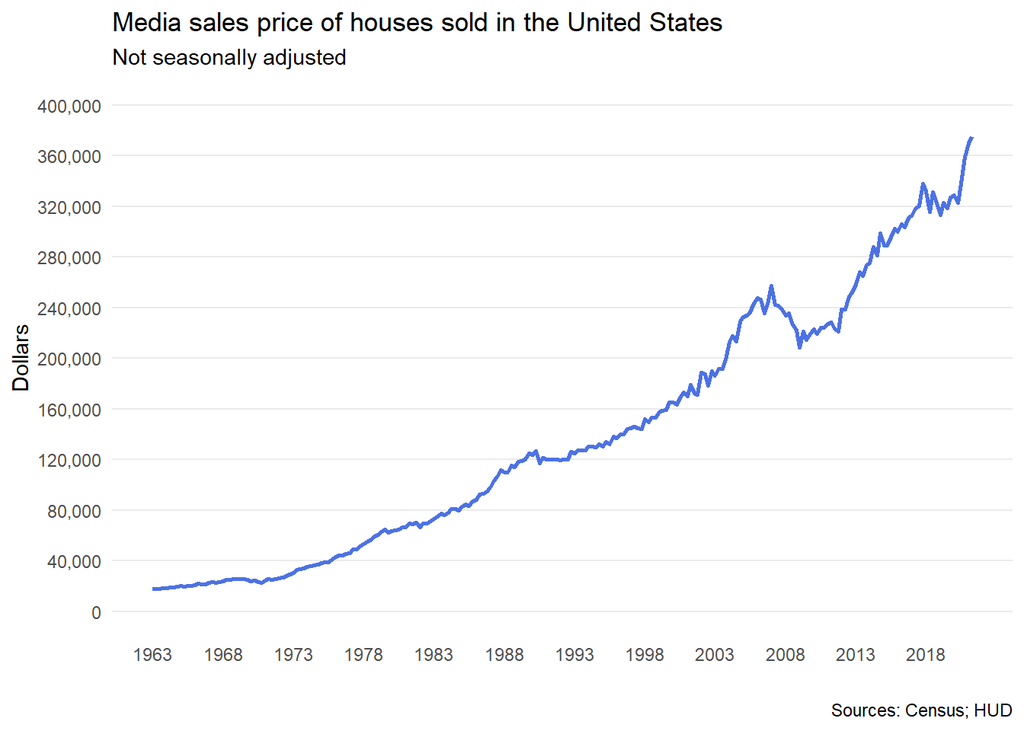

```r
ggplot(data = housing,
          aes(x = date,
              y = price)
       ) +
  geom_line(linewidth = 1, color = "#4D72E3") +
  ylim(0, 400000) +
  # guides(color = guide_legend(title = "Party")) +
  scale_y_continuous(limits = c(0, 400000),
                     breaks = seq(from = 0, to = 400000, by = 40000),
                     labels = label_comma()) +
  scale_x_date(
    limits = as.Date(c("1963-01-01", "2021-04-01")),
    breaks = seq(as.Date("1963-01-01"),
                 as.Date("2021-04-01"),
                 by = "5 years"),
    labels = format(seq(as.Date("1963-01-01"),
                        as.Date("2021-04-01"),
                        by = "5 years"), "%Y")) +
  theme_minimal() +
  theme(
    panel.grid.major.x = element_blank(),
    panel.grid.minor.x = element_blank(),
    panel.grid.major.y = element_line(),
    panel.grid.minor.y = element_blank()
  ) +
  labs(title = "Media sales price of houses sold in the United States",
       subtitle = "Not seasonally adjusted",
       x = "",
       y = "Dollars",
       caption = "Sources: Census; HUD")
```

```r
recessions <- read_csv(here("data", "recessions.csv"),
                    show_col_types = FALSE)
```

```r
recessions <- recessions |>
  mutate(
    during = ifelse(
      (Peak >= min(housing$date) & Trough <= max(housing$date)),
      TRUE,
      FALSE
      )
    )
```

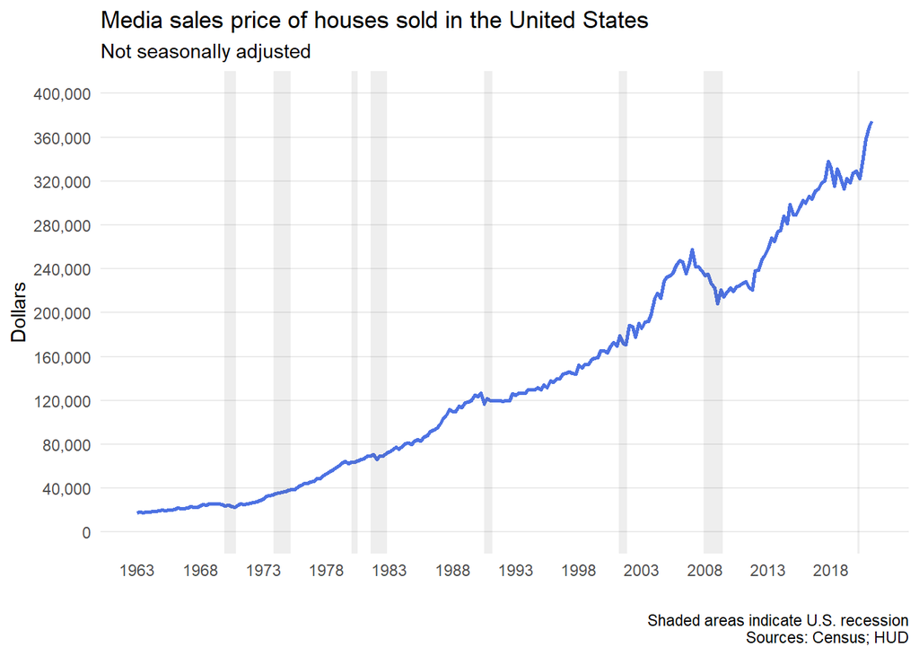

```r
ggplot(housing, aes(x = date, y = price)) +
  geom_line(linewidth = 1, color = "#4D72E3") +
  geom_rect(
    data = filter(recessions, recessions$during == TRUE),
    aes(xmin = Peak, xmax = Trough, ymin = -Inf, ymax = Inf),
    alpha = 0.1, inherit.aes = FALSE) +
  labs(title = "Time Series with Shaded Periods", x = "Date", y = "Value") +
  ylim(0, 400000) +
  scale_y_continuous(limits = c(0, 400000),
                     breaks = seq(from = 0, to = 400000, by = 40000),
                     labels = label_comma()) +
  scale_x_date(
    limits = as.Date(c("1963-01-01", "2021-04-01")),
    breaks = seq(as.Date("1963-01-01"),
                 as.Date("2021-04-01"),
                 by = "5 years"),
    labels = format(seq(as.Date("1963-01-01"),
                        as.Date("2021-04-01"),
                        by = "5 years"), "%Y")) +
  theme_minimal() +
  theme(
    panel.grid.major.x = element_blank(),
    panel.grid.minor.x = element_blank(),
    panel.grid.major.y = element_line(),
    panel.grid.minor.y = element_blank()
  ) +
  labs(title = "Media sales price of houses sold in the United States",
       subtitle = "Not seasonally adjusted",
       x = "",
       y = "Dollars",
       caption = "Shaded areas indicate U.S. recession
       Sources: Census; HUD")
```

```r
library(lubridate)
library(dplyr )


housing_filter <- housing |>
  mutate(
    year = as.numeric(format(date, "%Y")),
    quarter = paste0("Q", quarter(date))
    )

housing_filter <- housing_filter |>
  mutate(
    year_quarter = paste0(year, " ", quarter)
    )

housing_filter <- filter(housing_filter, (year >= 2019 & year <= 2020))
```

```r
housing_filter$year[duplicated(housing_filter$year)] <- NA
```

[figure not shown]

```r
ggp <- ggplot(housing_filter, aes(date, price)) +    # Draw ggplot2 plot with one axis
  geom_line(linewidth = 1, color = "#4D72E3") +
  geom_point(size = 3, color = "#4D72E3",
             fill = "white", shape = 21)

ggp +                               # Draw ggplot2 plot with multiple axes
  theme(plot.margin = unit(c(1, 1, 4, 1), "lines"),
        axis.title.x = element_blank(),
        axis.text.x = element_blank())  +
  coord_cartesian(clip = "off") +
  annotate(geom = "text",
           x = housing_filter$date,
           y = min(housing_filter$price),
           label = housing_filter$quarter,
           vjust = 3.5) +
  annotate(geom = "text",
           x = c(housing_filter$date[3]-45),
           y = min(housing_filter$price),
           label = c(2019),
           vjust = 5) +
  annotate(geom = "text",
           x = c(housing_filter$date[7]-45),
           y = min(housing_filter$price),
           label = c(2020),
           vjust = 5)+
  theme_minimal() +
  labs(title = "Media sales price of houses sold in the United States",
       subtitle = "Not seasonally adjusted",
       x = "",
       y = "Dollars",
       caption = "Shaded areas indicate U.S. recession
       Sources: Census; HUD")+
  theme(axis.ticks.x = element_blank()) +
  theme(axis.text.x = element_blank())
```

Sources:

1. https://www.youtube.com/watch?v=KoAJZYEOwSE
2. https://www.youtube.com/watch?v=hgkraz62M1I

## 4 - Expect More. Plot More.

[figure not shown]

```r
ggplot(data.frame(x=1, y=2), aes(x=x, y=y)) +
  geom_point(size = 125, color = "#E82118",
             fill = "white", shape = 21, stroke = 45) +
  geom_point(col="#E82118", size=60) +
  annotate("text",
            x = 1,
            y = 0.75,
            label = "TARGET",
            size = 20,
            color = "#E82118", fontface = "bold") +
  ylim(0, 4) +
  xlim(0.5, 1.5) +
  annotate("point",
            x = 1.185,
            y = 0.65, color = "#E82118", size = 15) +
  annotate("point",
            x = 1.185,
            y = 0.65, color = "white", size = 13) +
  annotate("text",
            x = 1.185,
            y = 0.65,
            label = "R",
            size = 7,
            color = "#E82118", fontface = "bold") +
  theme_void()
```

Sources:

1. https://ggplot2.tidyverse.org/reference/annotate.html

## 5 - Mirror, mirror on the wall, who’s the ugliest of them all?

```r
data(package = 'palmerpenguins')
```

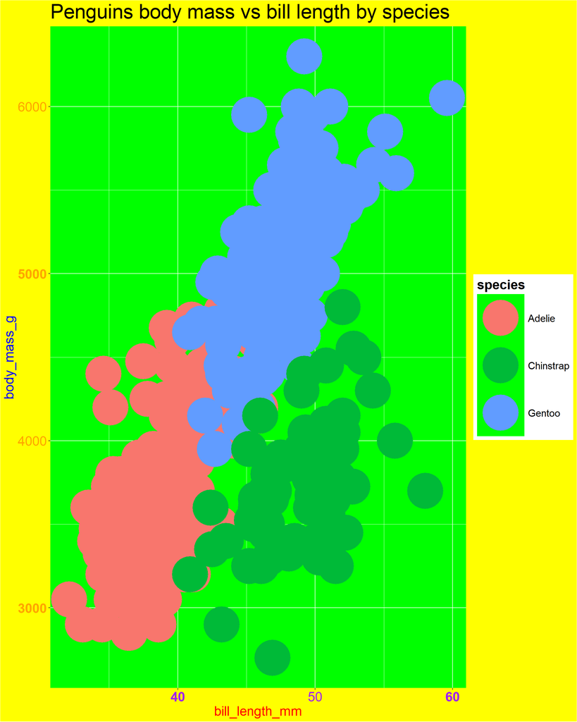

```r
ggplot(penguins, aes(x = bill_length_mm, y = body_mass_g, color = species)) +
  geom_point(size=25)+
  theme(plot.background = element_rect(fill = "yellow"),
      panel.background = element_rect(fill = "green"),
      axis.title.x = element_text(colour = "red", size = 20),
      axis.title.y = element_text(colour = "blue", size = 20),
      axis.text.x = element_text(color = "purple",
        size =20,
        face=c("bold","plain")
        ),
      axis.text.y = element_text(color = "orange",
        size =20,
        face=c("bold","plain")
        ),
        plot.title = element_text(size = 30),
        legend.text = element_text(size=15),
        legend.title = element_text(size = 20, face = "bold")
      ) +
  labs(title = "Penguins body mass vs bill length by species")
```